# First meeting

# 1. Introduction to the project

## 1.1 Outline

- Period: April 2021 - March 2023
- Obligation:
  - Members: meetings (up to once a month), field surveys (about once a year), co-authoring a book (final draft by March 2023)
  - Observers: none (valuable comments)
- Output: An [electronic book](https://bookdown.org/) (free for reading online, hard copy can be ordered with cost)

## 1.2 Motivation

Proliferation of [big data](https://www.oracle.com/big-data/what-is-big-data/) with low or almost no cost. But it is difficult to

- identify (locate) potential data for specific research
- process the data into required unit of analysis

Some examples:

[light every night (World Bank)](https://blogs.worldbank.org/opendata/light-every-night-new-nighttime-light-data-set-and-tools-development)

[World-Scale OpenStreetMap POIS in CSV (SLIPO)](http://slipo.eu/?p=1551)

## 1.3 Schedule

Fiscal 2021

- Compile an extensive list of potential big data with description from
  - remote sensing data in [google earth engine](https://earthengine.google.com/)
  - including others in [opendata at aws](https://registry.opendata.aws/)
  - what else…
- Aggregate NTL and Land cover data by adm2 in [GAUL](https://data.apps.fao.org/map/catalog/srv/eng/catalog.search#/search?any=gaul) and publish them onlie

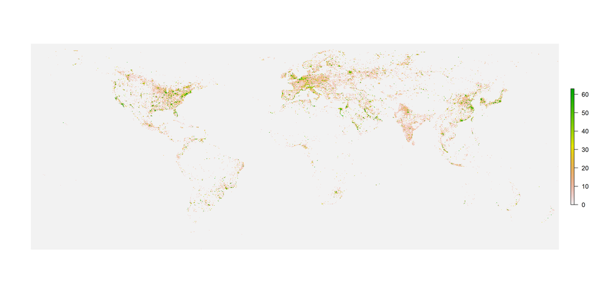

Remote sensing data

+

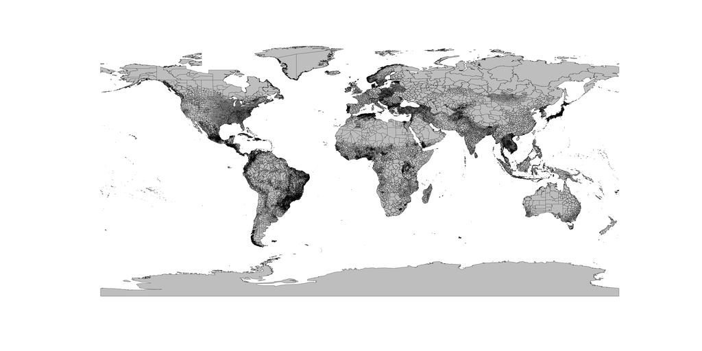

Boundaries

=

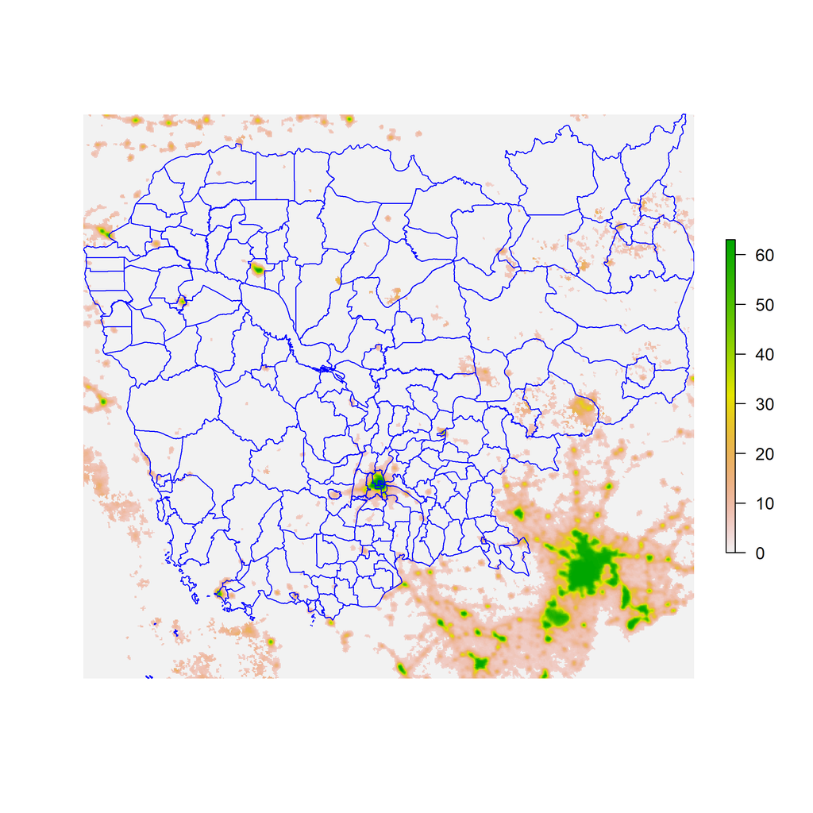

e.g. nighttime light in Cambodia by adm2

Fiscal 2022

- Task-oriented codes ([R](https://www.r-project.org/index.html), [Python](https://www.python.org/)) with one-clicked copy button and are
  - concise
  - short
  - reusable
  - beginner-proof
- Draft text to accompany data and codes
- Put them together to make an electronic book

# 2. Self introduction session

# 3. Tools

## 3.1 Github

- [Git](https://git-scm.com/)

Global Information Tracker. A version tracker that help programmers to work together in a project.

- [Github](https://github.com/)

A provider of Internet hosting for software development and version control using Git.

- Easy to collaborate and develop
  - monitor progress, contribution
  - report problems
  - resolve problems
- Easy to share the results
  - one-clicked button to download codes, files or the entire repository

## 3.2 R and Python

- [R](https://www.r-project.org/) and [Rstudio](https://www.rstudio.com/) : A democratization of programming
  - easy syntax (grammar)
  - free
  - interactive
  - expanding user-contributed packages
  - several cloud based environments
    - [R Cloud](https://rstudio.cloud/)
    - [R in colaboratory](https://colab.research.google.com/#create=true&language=r)
  - bad memory management
  - can be very slow in certain use cases
- Python
  - easy syntax (a bit more difficult than R)
  - free
  - native (almost) support in google earth engine
  - popularity (used by major global IT firms)
    - [colaboratory](https://colab.research.google.com/#create=true)

## 3.3 Bookdown

[How to bookdown?](https://bookdown.org/yihui/bookdown/)

[Spatial data science (Edzer Pebesmaand Roger Bivand)](https://keen-swartz-3146c4.netlify.app/)